# NYC Taxi Trip Duration Analysis

[figure not shown]

### **Problem Statement Overview**

There are 13,587 taxis in New York City. The fare depends on the duration of each trip along with other factors. The dataset is one released by the NYC Taxi and Limousine Commission, which includes pickup time, geo-coordinates, number of passengers, and several other variables. We seek to analyze the trip duration of a taxi trip in New York City based on the features available.

### **Datasets Overview**

The main data set has around 1.5mn records of taxi trips across New York for the year 2016. https://www.kaggle.com/c/nyc-taxi-trip-duration/data

The features are described below:

- id - a unique identifier for each trip
- vendor_id : A code indicating the provider associated with the trip record
- pickup_datetime : Date and time when the meter was engaged
- dropoff_datetime : Date and time when the meter was disengaged
- passenger_count : The number of passengers in the vehicle (driver entered value)
- pickup_longitude : The longitude where the meter was engaged
- pickup_latitude : The latitude where the meter was engaged
- dropoff_longitude : The longitude where the meter was disengaged
- dropoff_latitude : The latitude where the meter was disengaged
- store_and_fwd_flag: This flag indicates whether the trip record was held in vehicle memory before sending to the vendor because the vehicle did not have a connection to the server. Y=store and forward, N=not a store and forward trip
- trip_duration : Duration of the trip in seconds

I will be importing a helper dataset that has OSMR (Open Street Map Routing) data mapped out for each ID in the main dataset. I will only use the route distance column from this dataset.

The features for this helper dataset are described below:

- id: Record id
- distance: Route distance (m)

### **Approach**

- Importing Libraries and Datasets
- Feature Generation - Generating additional columns required for analysis
- Data Cleaning - NULL value and outlier identification and treatment
- Exploratory Data Analysis - Generating insights on what factors influence trip duration

### **Importing Libraries and Datasets, Feature Generation**

```r
library(tidyverse)
```

```r
train <- read.csv('E:/Arvind/Masters/UC Course Material/BANA 6043 - STAT COMPUTING/HW/Project/Data/train.csv')

# Feature generation

train$pickup_datetime_only_hour <- paste(substring(train$pickup_datetime,1,13), ":00:00", sep = "")

train$pickup_date_substr <- substring(train$pickup_datetime, 1, 10)

train$pickup_day <- format(as.Date(train$pickup_date_substr,format="%Y-%m-%d"), format = "%d")

train$pickup_month <- format(as.Date(train$pickup_date_substr,format="%Y-%m-%d"), format = "%m")

train$pickup_day_of_week <- format(c("Sunday", "Monday", "Tuesday", "Wednesday", "Thursday","Friday", "Saturday")[as.POSIXlt(train$pickup_date_substr)$wday + 1])

train$pickup_hour <- format(as.POSIXct(train$pickup_datetime_only_hour,format="%Y-%m-%d %H:%M:%S"), format = "%H")

# Importing and joining with osmr data

train_augmented <- read.csv('E:/Arvind/Masters/UC Course Material/BANA 6043 - STAT COMPUTING/HW/Project/Data/train_augmented.csv')

final_train <- left_join(train, train_augmented[,c("id","distance")], by = "id" )
```

```r
head(final_train)
```

```
##          id vendor_id     pickup_datetime    dropoff_datetime passenger_count
## 1 id2875421         2 2016-03-14 17:24:55 2016-03-14 17:32:30               1
## 2 id2377394         1 2016-06-12 00:43:35 2016-06-12 00:54:38               1
## 3 id3858529         2 2016-01-19 11:35:24 2016-01-19 12:10:48               1
## 4 id3504673         2 2016-04-06 19:32:31 2016-04-06 19:39:40               1
## 5 id2181028         2 2016-03-26 13:30:55 2016-03-26 13:38:10               1
## 6 id0801584         2 2016-01-30 22:01:40 2016-01-30 22:09:03               6
##   pickup_longitude pickup_latitude dropoff_longitude dropoff_latitude
## 1        -73.98215        40.76794         -73.96463         40.76560
## 2        -73.98042        40.73856         -73.99948         40.73115
## 3        -73.97903        40.76394         -74.00533         40.71009
## 4        -74.01004        40.71997         -74.01227         40.70672
## 5        -73.97305        40.79321         -73.97292         40.78252
## 6        -73.98286        40.74220         -73.99208         40.74918
##   store_and_fwd_flag trip_duration pickup_datetime_only_hour pickup_date_substr
## 1                  N           455       2016-03-14 17:00:00         2016-03-14
## 2                  N           663       2016-06-12 00:00:00         2016-06-12
## 3                  N          2124       2016-01-19 11:00:00         2016-01-19
## 4                  N           429       2016-04-06 19:00:00         2016-04-06
## 5                  N           435       2016-03-26 13:00:00         2016-03-26
## 6                  N           443       2016-01-30 22:00:00         2016-01-30
##   pickup_day pickup_month pickup_day_of_week pickup_hour distance
## 1         14           03          Monday             17   2009.1
## 2         12           06          Sunday             00   2513.4
## 3         19           01          Tuesday            11   9910.7
## 4         06           04          Wednesday          19   1779.1
## 5         26           03          Saturday           13   1615.0
## 6         30           01          Saturday           22   1393.6
```

```r
str(final_train)
```

```
## 'data.frame':    1458644 obs. of  18 variables:
##  $ id                       : chr  "id2875421" "id2377394" "id3858529" "id3504673" ...
##  $ vendor_id                : int  2 1 2 2 2 2 1 2 1 2 ...
##  $ pickup_datetime          : chr  "2016-03-14 17:24:55" "2016-06-12 00:43:35" "2016-01-19 11:35:24" "2016-04-06 19:32:31" ...
##  $ dropoff_datetime         : chr  "2016-03-14 17:32:30" "2016-06-12 00:54:38" "2016-01-19 12:10:48" "2016-04-06 19:39:40" ...
##  $ passenger_count          : int  1 1 1 1 1 6 4 1 1 1 ...
##  $ pickup_longitude         : num  -74 -74 -74 -74 -74 ...
##  $ pickup_latitude          : num  40.8 40.7 40.8 40.7 40.8 ...
##  $ dropoff_longitude        : num  -74 -74 -74 -74 -74 ...
##  $ dropoff_latitude         : num  40.8 40.7 40.7 40.7 40.8 ...
##  $ store_and_fwd_flag       : chr  "N" "N" "N" "N" ...
##  $ trip_duration            : int  455 663 2124 429 435 443 341 1551 255 1225 ...
##  $ pickup_datetime_only_hour: chr  "2016-03-14 17:00:00" "2016-06-12 00:00:00" "2016-01-19 11:00:00" "2016-04-06 19:00:00" ...
##  $ pickup_date_substr       : chr  "2016-03-14" "2016-06-12" "2016-01-19" "2016-04-06" ...
##  $ pickup_day               : chr  "14" "12" "19" "06" ...
##  $ pickup_month             : chr  "03" "06" "01" "04" ...
##  $ pickup_day_of_week       : chr  "Monday   " "Sunday   " "Tuesday  " "Wednesday" ...
##  $ pickup_hour              : chr  "17" "00" "11" "19" ...
##  $ distance                 : num  2009 2513 9911 1779 1615 ...
```

### **Data Cleaning**

- 1 NULL in distance and 1 NULL in pickup_hour, we will delete the row for distance and force replace/hard code for pickup hour
- No duplicates at ID level
- Passenger count 9 seems like an outlier
- Trip duration max is 3,526,282, seemed like an outlier. As a follow up I have checked the distance vs trip duration scatter and it still seems like an outlier. I will be keeping the record for now

```r
# Checking for NULLs

colSums(is.na(final_train))
```

```
##                        id                 vendor_id           pickup_datetime
##                         0                         0                         0
##          dropoff_datetime           passenger_count          pickup_longitude
##                         0                         0                         0
##           pickup_latitude         dropoff_longitude          dropoff_latitude
##                         0                         0                         0
##        store_and_fwd_flag             trip_duration pickup_datetime_only_hour
##                         0                         0                         0
##        pickup_date_substr                pickup_day              pickup_month
##                         0                         0                         0
##        pickup_day_of_week               pickup_hour                  distance
##                         0                         1                         1
```

```r
# Dropping the row with NULL for distance

final_train <- final_train %>% filter(is.na(distance) == FALSE)
```

```r
# and replacing the NULL for pickup_hour

print(final_train %>% filter(is.na(pickup_hour) == TRUE))
```

```
##          id vendor_id     pickup_datetime    dropoff_datetime passenger_count
## 1 id0253317         1 2016-03-13 02:03:49 2016-03-13 02:14:13               1
##   pickup_longitude pickup_latitude dropoff_longitude dropoff_latitude
## 1        -73.99203        40.74913         -73.96436         40.75791
##   store_and_fwd_flag trip_duration pickup_datetime_only_hour pickup_date_substr
## 1                  N           624       2016-03-13 02:00:00         2016-03-13
##   pickup_day pickup_month pickup_day_of_week pickup_hour distance
## 1         13           03          Sunday           <NA>   4109.4
```

```r
final_train$pickup_hour[is.na(final_train$pickup_hour)] <- 2
```

```r
# Checking for NULLs again

colSums(is.na(final_train))
```

```
##                        id                 vendor_id           pickup_datetime
##                         0                         0                         0
##          dropoff_datetime           passenger_count          pickup_longitude
##                         0                         0                         0
##           pickup_latitude         dropoff_longitude          dropoff_latitude
##                         0                         0                         0
##        store_and_fwd_flag             trip_duration pickup_datetime_only_hour
##                         0                         0                         0
##        pickup_date_substr                pickup_day              pickup_month
##                         0                         0                         0
##        pickup_day_of_week               pickup_hour                  distance
##                         0                         0                         0
```

```r
# Checking for duplicates

length(unique(final_train$id))
```

```
## [1] 1458643
```

```r
# Checking for outliers

summary(final_train)
```

```
##       id              vendor_id     pickup_datetime    dropoff_datetime
##  Length:1458643     Min.   :1.000   Length:1458643     Length:1458643
##  Class :character   1st Qu.:1.000   Class :character   Class :character
##  Mode  :character   Median :2.000   Mode  :character   Mode  :character
##                     Mean   :1.535
##                     3rd Qu.:2.000
##                     Max.   :2.000
##  passenger_count pickup_longitude  pickup_latitude dropoff_longitude
##  Min.   :0.000   Min.   :-121.93   Min.   :34.36   Min.   :-121.93
##  1st Qu.:1.000   1st Qu.: -73.99   1st Qu.:40.74   1st Qu.: -73.99
##  Median :1.000   Median : -73.98   Median :40.75   Median : -73.98
##  Mean   :1.665   Mean   : -73.97   Mean   :40.75   Mean   : -73.97
##  3rd Qu.:2.000   3rd Qu.: -73.97   3rd Qu.:40.77   3rd Qu.: -73.96
##  Max.   :9.000   Max.   : -61.34   Max.   :51.88   Max.   : -61.34
##  dropoff_latitude store_and_fwd_flag trip_duration
##  Min.   :32.18    Length:1458643     Min.   :      1
##  1st Qu.:40.74    Class :character   1st Qu.:    397
##  Median :40.75    Mode  :character   Median :    662
##  Mean   :40.75                       Mean   :    959
##  3rd Qu.:40.77                       3rd Qu.:   1075
##  Max.   :43.92                       Max.   :3526282
##  pickup_datetime_only_hour pickup_date_substr  pickup_day
##  Length:1458643            Length:1458643     Length:1458643
##  Class :character          Class :character   Class :character
##  Mode  :character          Mode  :character   Mode  :character
##
##
##
##  pickup_month       pickup_day_of_week pickup_hour           distance
##  Length:1458643     Length:1458643     Length:1458643     Min.   :      0
##  Class :character   Class :character   Class :character   1st Qu.:   1654
##  Mode  :character   Mode  :character   Mode  :character   Median :   2730
##                                                           Mean   :   4569
##                                                           3rd Qu.:   5049
##                                                           Max.   :1038310
```

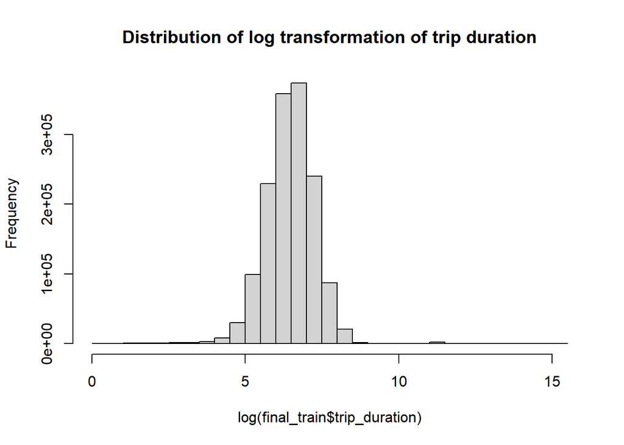

```r
# Taking log because otherwise the outlier in trip duration is really huge

hist(log(final_train$trip_duration),
     main = "Distribution of log transformation of trip duration")
```

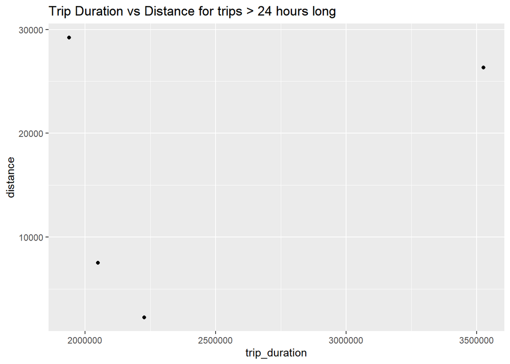

```r
# Let us see the distance between pickup and drop location and see if it actually makes sense for trips > 24 hours (86,400 secs)

final_train %>%
  filter(trip_duration>=86400) %>%
    ggplot(aes(x=trip_duration,y=distance)) +
      geom_point() +
        ggtitle("Trip Duration vs Distance for trips > 24 hours long")
```

### **Exploratory Data Analysis**

1. passenger count vs trip duration

From the below chart we see that average trip duration is around 1000. There are a few issues here:

- For passenger count 0, we see high average trip duration of 1,718 seconds. Firstly, there should not be trips with 0 passengers. Secondly, the average seems high. There are 60 such rows
- We see 5 rows where passenger count is 7, 8, 9. The average trip duration is also low for them but I am not reading too much into it because of the low number of instances

```
## # A tibble: 10 x 3
##    passenger_count average_trip_duration row_count
##              <int>                 <dbl>     <int>
##  1               0                1718.         60
##  2               1                 930.    1033539
##  3               2                1005.     210318
##  4               3                1028.      59896
##  5               4                1054.      28404
##  6               5                1070.      78088
##  7               6                1061.      48333
##  8               7                  19.7         3
##  9               8                 104           1
## 10               9                 560           1
```

2. distance vs trip duration

Looks like trip duration is not purely dependent on distance, otherwise we would get a linear trend here. Maybe it is more dependent on time series columns like month, day of week etc.

For the datapoints that don’t fit into the expected trend, below are my hypothesis:

- High trip duration, low distance – It is possible that the dropoff location was very close to the pickup but there were other stops along the way
- High distance, low trip duration – The OSMR data maybe incorrect or the latitude, longitude maybe incorrectly captured

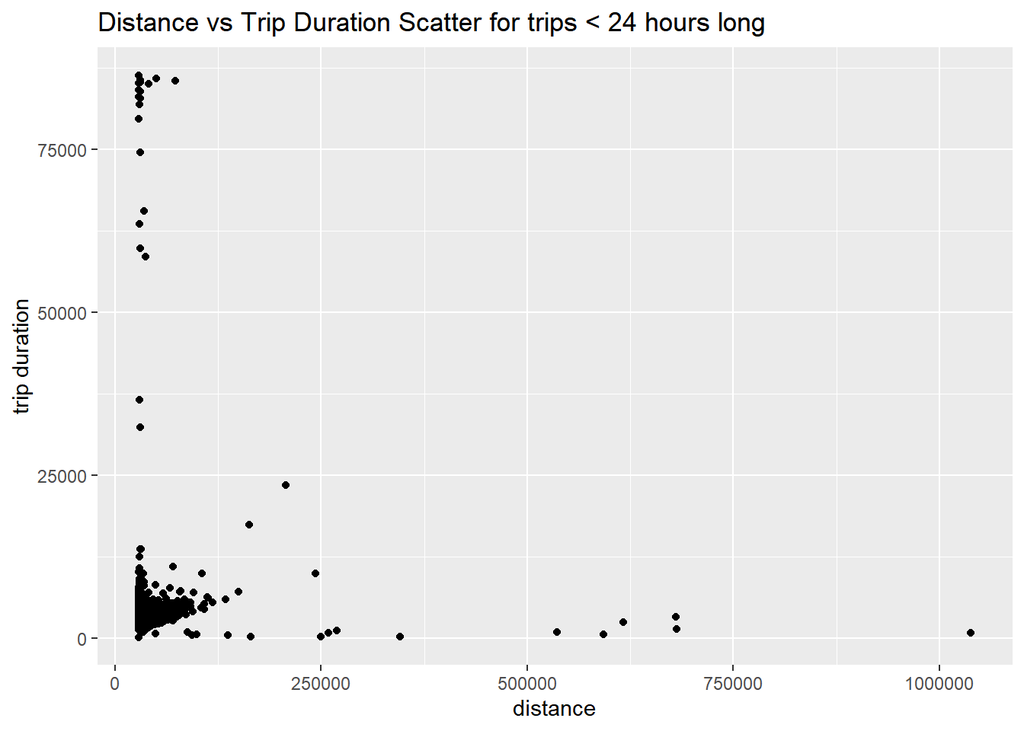

3. month vs trip duration

For the 6 months of data that we have, we notice that average trip duration is more or less the same. The average seems to increase from January to June.

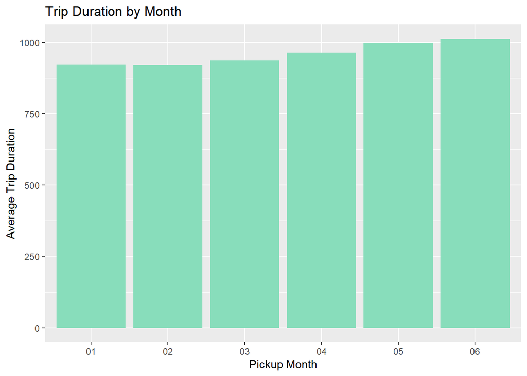

4. month, day of month vs trip duration

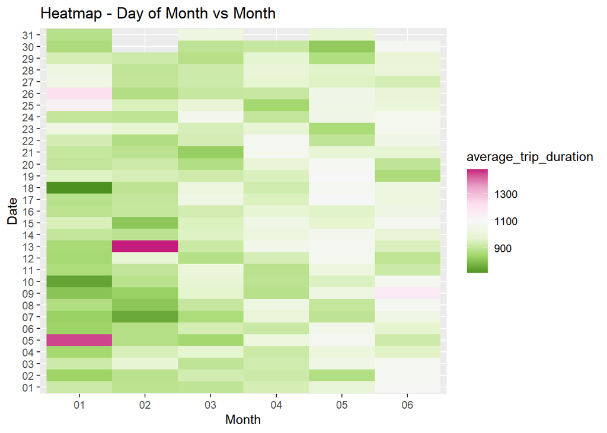

5. day of week, hour of day vs trip duration

When we plot the mean trip duration for day of week vs hour of day, we see:

- Highest average trip duration is seen at 10 PM on Saturdays
- High average trip durations are also seen 11-5 on weekdays (except Monday), this is likely because of traffic

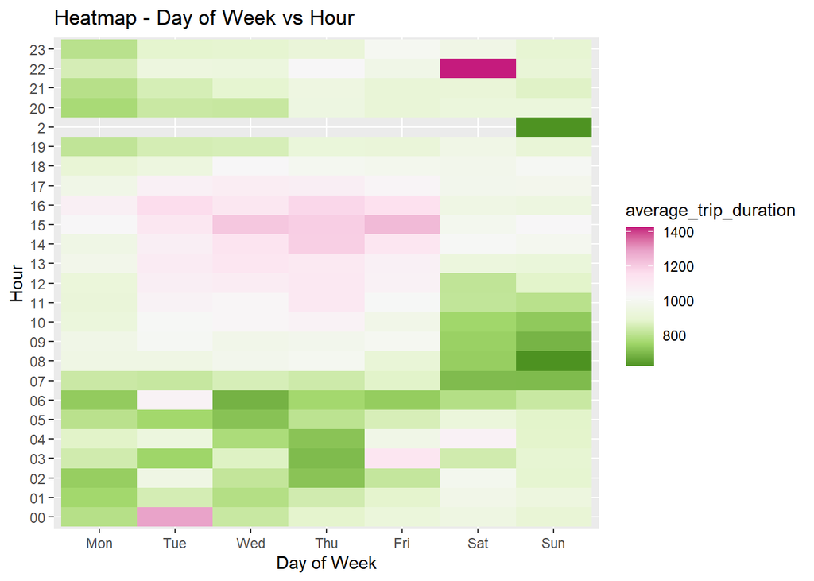

6. vendor ID vs trip duration

Median and average trip duration is higher for vendor ID 2. Along the same lines ratio of total distance covered to total trip duration (rate metric) is lower for vendor 2.

```
## # A tibble: 2 x 5
##   vendor_id average_trip_durat~ median_trip_durat~ ratio_distance_by_~ row_count
##       <int>               <dbl>              <dbl>               <dbl>     <int>
## 1         1                845.                658                5.34    678342
## 2         2               1059.                666                4.36    780301
```